# Text Mining with R

R is a programming language with a number of advanced packages for text mining. Unlike the previous tools, R requires you to use a ‘command line interface’, meaning you have to type code rather than use an graphical user interface.

This document won’t teach you how to code, but it’s intended to give you a flavour of the kind of things you can do with text and a progamming language. If you already know some R, then you can feel free to manipulate the examples in the code below.

A good place to start to learn R is the free book https://r4ds.had.co.nz/index.html, and if you want to learn how to use R for text mining specifically, https://www.tidytextmining.com/ is an excellent (also free) online book.

This document you’re reading is called an R Notebook: it’s a special document which contains text *and* code. Anything within the gray block below is called a ‘chunk’. On the right-hand side you’ll see a little green triangle. Clicking that will run all the code in the chunk. 1 + 1 is very simple computer code which adds those two numbers together. Try clicking on the code.

```r
1+1
```

```
[1] 2
```

R runs the code, and displays the output underneath the chunk

The programming language R is supplemented with what are known as *packages*. These are bundles of additional functions created by third-parties. Some are developed to do very specific tasks, and others are much more general. We need two to do text mining with R: `tidyverse`, which is a huge collection of tools to generally extend the functionality of R, and `tidytext`, which was developed specifically to work with text. You need to run the chunk below to load these packages (the functionality won’t be available otherwise)

```r
library(tidyverse)
library(tidytext)
```

Next we need some text. The easiest place to start is with the `janeaustenr` package.

```r
library(janeaustenr)
austen_books = janeaustenr::austen_books()
```

```r
holmes_tbl = holmes %>% as_tibble() %>% slice(-1:63) %>%  mutate(
         chapter = cumsum(str_detect(value, "[A-Z]{1,3}\\.")))
```

[output not shown]

Now that we have the text we can analyse it. First run a function called `unnest_tokens`, which creates a dataset containing each word on a single line. We can then use R functions to sort and count the words:

```r
austen_tokens = austen_books %>% unnest_tokens(text, word)
```

[output not shown]

First, a simple count of the top words:

| word | n |
| --- | --- |
| the | 26351 |
| to | 24044 |
| and | 22515 |
| of | 21178 |
| a | 13408 |
| her | 13055 |
| i | 12006 |
| in | 11217 |
| was | 11204 |
| it | 10234 |

[output cut: 10 more lines]

Unsurprisingly they are all short function words like ‘the’, ‘and’ and so forth. We can remove these, and make a small chart of the results:

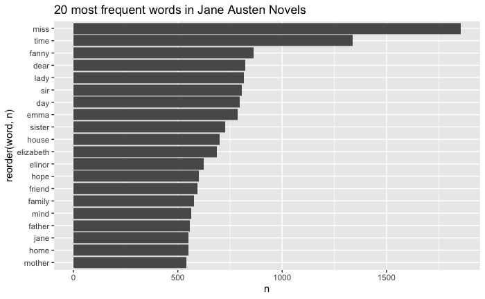

```r
austen_tokens %>%
  anti_join(stop_words) %>%
  group_by(word) %>%
  tally() %>%
  arrange(desc(n)) %>%
  head(20) %>%
  ggplot() +
  geom_col(aes(x = reorder(word,n), y = n)) +
  coord_flip() +
  labs(title = "20 most frequent words in Jane Austen Novels")
```

We can also count the words per novel:

| book | words |
| --- | --- |
| Sense & Sensibility | 119957 |
| Pride & Prejudice | 122204 |
| Mansfield Park | 160460 |
| Emma | 160996 |
| Northanger Abbey | 77780 |
| Persuasion | 83658 |

Or chart the appearance of a word in a single book. Try swapping out the book name or word name between the inverted commas below, to count other words.

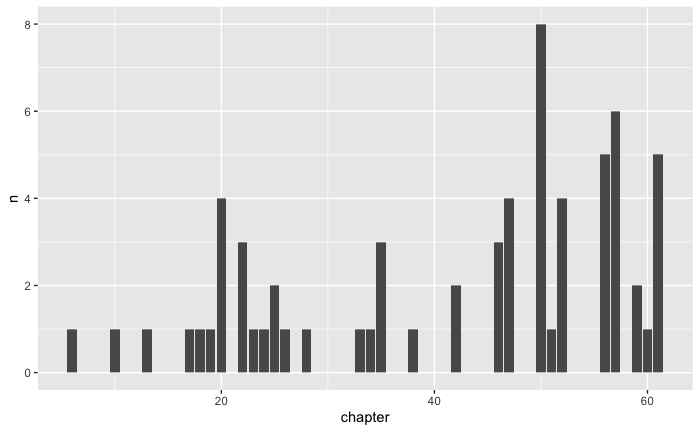